# Cancer Genome Sequencing Report by PCGR

October 27, 2020

## Settings

### Metadata - sample and sequencing assay

- Sample name: **PCB-2020-005**
- Tumor primary site: **CNS/Brain**
- Sequencing mode input (VCF): **Tumor-Control**
- Sequencing type input (VCF): **WGS**
- Coding target size (VCF): **34 Mb**

### Report configuration

The report is generated with *[PCGR](https://github.com/sigven/pcgr)* version 0.9.0rc, using the following key settings:

- Minimum sequencing depth (DP) tumor (SNV + InDels): **0**
- Minimum allelic fraction (AF) tumor (SNV + InDels): **0**
- Minimum sequencing depth (DP) control (SNV + InDels): **0**
- Maximum allelic fraction (AF) control (SNV + InDels): **1**
- Tier system (VCF): **pcgr_acmg**
- MSI prediction: **ON**
- Mutational burden estimation: **ON**
- Mutational signatures estimation: **ON**
- Report theme (Bootstrap): **default**

## Main results

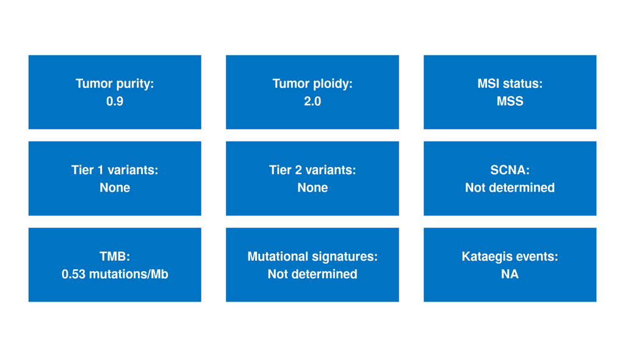

## Somatic SNVs/InDels

### Tumor mutational burden (TMB)

The size of the targeted (coding) genomic region has been defined as: **34 Mb**. For estimation of TMB, PCGR employs the same approach as was outlined in a recently published large-scale study of TMB [(Chalmers et al. 2017)](https://www.ncbi.nlm.nih.gov/pubmed/28420421), i.e. counting all coding, somatic base substitutions and indels in the targeted regions, including synonymous alterations.

Estimated mutational burden: **0.53** **mutations/Mb**

#### TMB reference distributions - TCGA

- The TCGA tumor samples are sequenced with a mean coverage of approximately 100X
- The TCGA somatic mutation calls are based on a consensus among variant callers (each variant is supported by a minimum of two variant calling algorithms)
- The TCGA somatic mutation calls are based on paired tumor-control sequencing (tumor-only sequencing may produce higher numbers due to more noise)

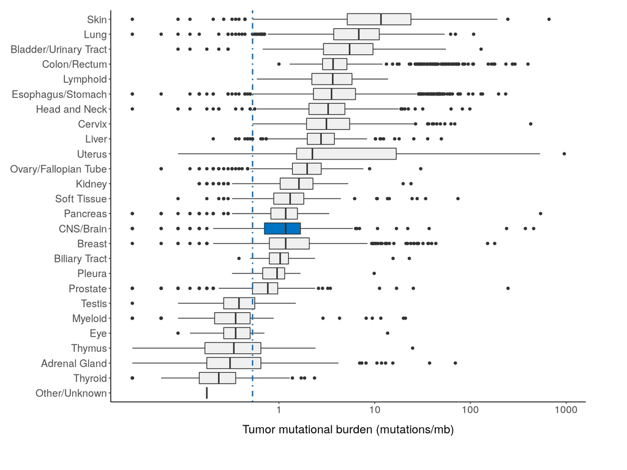

### Tier & variant statistics

- Number of SNVs: **61**
- Number of InDels: **0**
- Number of protein-coding variants: **14**

The prioritization of SNV/InDels is here done according to a four-tiered structure, adopting the joint consensus recommendation by AMP/ACMG [(Li et al. 2017)](https://www.ncbi.nlm.nih.gov/pubmed/27993330).

- Tier 1 - variants of strong clinical significance: **0**
- Tier 2 - variants of potential clinical significance: **0**
- Tier 3 - variants of unknown clinical significance: **2**
- Tier 4 - other coding variants: **12**
- Noncoding variants: **47**
- *Tumor sequencing depth and allelic fraction of variants not provided - omitting plot.*

### Global variant browser

The table below permits filtering of the total SNV/InDel set by various criteria.

**NOTE 1**: The filtering applies to this table only, and not to the tier-specific tables below.

**NOTE 2**: Filtering on sequencing depth/allelic fraction depends on input specified by user (VCF INFO tags).

Tier

Consequence

|  | SYMBOL | CONSEQUENCE | PROTEIN_CHANGE | VARIANT_CLASS | TIER | GENOMIC_CHANGE | GENOME_VERSION | CALL_CONFIDENCE | DP_TUMOR | AF_TUMOR | DP_CONTROL | AF_CONTROL |
| --- | --- | --- | --- | --- | --- | --- | --- | --- | --- | --- | --- | --- |
| 1 | FGFR1 | missense_variant | p.Lys687Asn | SNV | TIER 3 | 8:g.38272306C&gt;G | grch37 |  |  |  |  |  |
| 2 | FGFR1 | missense_variant | p.Asn577Lys | SNV | TIER 3 | 8:g.38274849G&gt;T | grch37 |  |  |  |  |  |
| 3 | GPR65 | missense_variant | p.Arg211Trp | SNV | TIER 4 | 14:g.88477822C&gt;T | grch37 |  |  |  |  |  |
| 4 | XCR1 | missense_variant | p.Glu260Lys | SNV | TIER 4 | 3:g.46062662C&gt;T | grch37 |  |  |  |  |  |
| 5 | CD200R1 | missense_variant | p.Gln59Glu | SNV | TIER 4 | 3:g.112649980G&gt;C | grch37 |  |  |  |  |  |
| 6 | PHC1 | missense_variant | p.Ala704Val | SNV | TIER 4 | 12:g.9086932C&gt;T | grch37 |  |  |  |  |  |
| 7 | ABHD2 | missense_variant | p.Gln284Arg | SNV | TIER 4 | 15:g.89731459A&gt;G | grch37 |  |  |  |  |  |
| 8 | NBPF15 | missense_variant | p.Thr239Ala | SNV | TIER 4 | 1:g.148582481A&gt;G | grch37 |  |  |  |  |  |
| 9 | PRR21 | missense_variant | p.Val210Leu | SNV | TIER 4 | 2:g.240981772C&gt;G | grch37 |  |  |  |  |  |
| 10 | OR2T33 | missense_variant | p.Ala221Ser | SNV | TIER 4 | 1:g.248436456C&gt;A | grch37 |  |  |  |  |  |

[output cut: 51 more lines]

### Tier 1 - Variants of strong clinical significance

- Considering evidence items with strongest evidence levels (A & B) for the query tumor type (*CNS/Brain*) in the [database for clinical interpretations of variants in cancer, CIViC](https://civic.genome.wustl.edu/#/home) or [Cancer Biomarkers database](https://www.cancergenomeinterpreter.org/biomarkers), a total of **0** unique, somatic variants were found, with the following number of evidence items:
  - Tier 1 - Predictive/Therapeutic: **0** evidence items
  - Tier 1 - Prognostic: **0** evidence items
  - Tier 1 - Diagnostic: **0** evidence items

#### Predictive biomarkers

*No variant-evidence item associations found.*

#### Prognostic biomarkers

*No variant-evidence item associations found.*

#### Diagnostic biomarkers

*No variant-evidence item associations found.*

### Tier 2 - Variants of potential clinical significance

- Tier 2 considers evidence items of *i)* strong evidence levels (A & B) in other tumor types, and *ii)* weak evidence levels (C, D & E) in the query tumor type (*CNS/Brain*). Using the [database for clinical interpretations of variants in cancer (CIViC)](https://civic.genome.wustl.edu/#/home) and [Cancer Biomarkers database](https://www.cancergenomeinterpreter.org/biomarkers), a total of **0** unique, somatic variants were found in the tumor sample:
  - Tier 2 - Predictive/Therapeutic: **0** evidence items
  - Tier 2 - Prognostic: **0** evidence items
  - Tier 2 - Diagnostic: **0** evidence items

#### Predictive biomarkers

*No variant-evidence item associations found.*

#### Prognostic biomarkers

*No variant-evidence item associations found.*

#### Diagnostic biomarkers

*No variant-evidence item associations found.*

### Tier 3 - Variants of unknown clinical significance

- A total of **2** unique, somatic variant(s) in the tumor sample are of unknown clinical significance, as found within known proto-oncogenes or tumor suppressor genes.

#### Tumor suppressor gene mutations

*No variants found.*

#### Proto-oncogene mutations

Consequence

Mutation hotspot

Predicted driver mutation

The table below lists all variants:

|  | SYMBOL | PROTEIN_CHANGE | GENE_NAME | PROTEIN_DOMAIN | CONSEQUENCE | MUTATION_HOTSPOT | COSMIC | HGVSp | HGVSc | NCBI_REFSEQ | CDS_CHANGE | PROTEIN_FEATURE | MUTATION_HOTSPOT_CANCERTYPE | PUTATIVE_DRIVER_MUTATION | PREDICTED_EFFECT | DBSNP | TCGA_FREQUENCY | ICGC_PCAWG_OCCURRENCE | CLINVAR | DOCM_LITERATURE | OPENTARGETS_ASSOCIATIONS | OPENTARGETS_RANK | DOCM_DISEASE | VEP_ALL_CSQ | CHEMBL_COMPOUND_TERMS | TARGETED_DRUGS | CANCER_ASSOCIATIONS | ONCOGENE | TUMOR_SUPPRESSOR | … |
| --- | --- | --- | --- | --- | --- | --- | --- | --- | --- | --- | --- | --- | --- | --- | --- | --- | --- | --- | --- | --- | --- | --- | --- | --- | --- | --- | --- | --- | --- | --- |
| 1 | FGFR1 | p.Lys687Asn | fibroblast growth factor receptor 1 | Protein tyrosine and serine/threonine kinase | missense_variant | FGFR1\|K687\|6.61e-12 | COSV58339958 | ENSP00000393312.3:p.Lys687Asn | ENST00000425967.3:c.2061G>C | NM_001174067 | missense_variant:ENST00000425967.3:c.2061G>C:exon15:p.K687N | TOPO_DOM:Cytoplasmic:398-822 | cnsbrain:1 | False | SIFT:damaging, SIFT4G:damaging, LRT:damaging, MutationTaster:damaging, MutationAssessor:tolerated, FATHMM:damaging, FATHMM-mkl:damaging, PROVEAN:damaging, M-CAP:damaging, MutPred:0.922, Ensembl-SVM:da… | rs1057519897 |  |  | Somatic - Hepatocellular carcinoma;Lymphoblastic leukemia, acute, with lymphomatous features;Transitional cell carcinoma of the bladder;Medulloblastoma;Astrocytoma;Glioblastoma | Chang et al., 2015, Nat. Biotechnol. | Astrocytoma, Astrocytoma, anaplastic, Cerebral astrocytoma, Childhood cerebral astrocytoma, Diffuse astrocytoma, Fibrillary astrocytoma, Gemistocytic astrocytoma, Juvenile pilocytic astrocytoma, Piloc… | 1 | pilocytic_astrocytoma, medulloblastoma, hepatocellular_carcinoma, urinary_bladder_urothelial_carcinoma, acute_lymphocytic_leukemia, glioblastoma_multiforme | missense_variant:FGFR1:Transcript:ENST00000326324:protein_coding, missense_variant:FGFR1:Transcript:ENST00000335922:protein_coding, missense_variant:FGFR1:Transcript:ENST00000341462:protein_coding, mi… | Brivanib, Orantinib, Nintedanib, Infigratinib, Erdafitinib, Regorafenib, Pazopanib, Sulfatinib | Brivanib, Orantinib, Nintedanib, Infigratinib, Erdafitinib, Regorafenib, Pazopanib, Sulfatinib | Familial cancer of breast, Breast carcinoma, Non-small cell lung cancer, Squamous cell carcinoma, Neoplasm of the breast, Mammary Neoplasms, Human, Astrocytoma, Malignant Lung Neoplasm, Pilocytic astr… | True | False | … |
| 2 | FGFR1 | p.Asn577Lys | fibroblast growth factor receptor 1 | Protein tyrosine and serine/threonine kinase | missense_variant | FGFR1\|N577\|5.28e-25 | COSV58329537, COSV58330551 | ENSP00000393312.3:p.Asn577Lys | ENST00000425967.3:c.1731C>A | NM_001174067 | missense_variant:ENST00000425967.3:c.1731C>A:exon13:p.N577K | TOPO_DOM:Cytoplasmic:398-822 | cnsbrain:11, adrenalgland:2, softtissue:2, breast:1, cervix:1 | False | SIFT:damaging, SIFT4G:damaging, LRT:damaging, MutationTaster:damaging, MutationAssessor:tolerated, FATHMM:damaging, FATHMM-mkl:damaging, PROVEAN:damaging, M-CAP:damaging, MutPred:0.774, Ensembl-SVM:da… | rs779707422 | Pheochromocytoma and Paraganglioma: 1.1% (2/179), Sarcoma: 0.4% (1/237), Uterine Corpus Endometrial Carcinoma: 0.4% (2/530), Brain Lower Grade Glioma: 0.2% (1/509) | PBCA-DE\|Primary\|3\|230\|0.013 | Germline,somatic - Encephalocraniocutaneous lipomatosis;Adenocarcinoma of stomach;Neuroblastoma;Brainstem glioma;Medulloblastoma;Astrocytoma;Rosette-forming glioneuronal tumor | Chang et al., 2015, Nat. Biotechnol. | Astrocytoma, Astrocytoma, anaplastic, Cerebral astrocytoma, Childhood cerebral astrocytoma, Diffuse astrocytoma, Fibrillary astrocytoma, Gemistocytic astrocytoma, Juvenile pilocytic astrocytoma, Piloc… | 1 | gastric_adenocarcinoma, neuroblastoma, medulloblastoma, brain_stem_glioma, pilocytic_astrocytoma | missense_variant:FGFR1:Transcript:ENST00000326324:protein_coding, missense_variant:FGFR1:Transcript:ENST00000335922:protein_coding, missense_variant:FGFR1:Transcript:ENST00000341462:protein_coding, mi… | Brivanib, Orantinib, Nintedanib, Infigratinib, Erdafitinib, Regorafenib, Pazopanib, Sulfatinib | Brivanib, Orantinib, Nintedanib, Infigratinib, Erdafitinib, Regorafenib, Pazopanib, Sulfatinib | Familial cancer of breast, Breast carcinoma, Non-small cell lung cancer, Squamous cell carcinoma, Neoplasm of the breast, Mammary Neoplasms, Human, Astrocytoma, Malignant Lung Neoplasm, Pilocytic astr… | True | False | … |

### Tier 4 - Other coding mutations

- A total of **12** unique, coding somatic variant(s) are also found in the tumor sample.

|  | SYMBOL | PROTEIN_CHANGE | GENE_NAME | PROTEIN_DOMAIN | CONSEQUENCE | COSMIC | NCBI_REFSEQ | HGVSp | HGVSc | CDS_CHANGE | PROTEIN_FEATURE | PREDICTED_EFFECT | DBSNP | TCGA_FREQUENCY | ONCOSCORE | ICGC_PCAWG_OCCURRENCE | CLINVAR | CANCER_ASSOCIATIONS | OPENTARGETS_RANK | OPENTARGETS_ASSOCIATIONS | KEGG_PATHWAY | TARGETED_DRUGS | VEP_ALL_CSQ | CALL_CONFIDENCE | DP_TUMOR | AF_TUMOR | DP_CONTROL | AF_CONTROL | GENOMIC_CHANGE | … |
| --- | --- | --- | --- | --- | --- | --- | --- | --- | --- | --- | --- | --- | --- | --- | --- | --- | --- | --- | --- | --- | --- | --- | --- | --- | --- | --- | --- | --- | --- | --- |
| 1 | GPR65 | p.Arg211Trp | G protein-coupled receptor 65 | 7 transmembrane receptor (rhodopsin family) | missense_variant |  | NM_003608 | ENSP00000267549.3:p.Arg211Trp | ENST00000267549.3:c.631C>T | missense_variant:ENST00000267549.3:c.631C>T:exon2:p.R211W |  | SIFT:damaging, SIFT4G:damaging, LRT:tolerated, MutationTaster:tolerated, MutationAssessor:damaging, FATHMM:tolerated, FATHMM-mkl:tolerated, PROVEAN:damaging, M-CAP:damaging, MutPred:NA, Ensembl-SVM:to… | rs781183577 |  | 0.405205 |  |  |  | 0.704151 | Astrocytoma, Astrocytoma, anaplastic, Cerebral astrocytoma, Childhood cerebral astrocytoma, Diffuse astrocytoma, Fibrillary astrocytoma, Gemistocytic astrocytoma, Juvenile pilocytic astrocytoma, Piloc… |  |  | missense_variant:GPR65:Transcript:ENST00000267549:protein_coding, intron_variant&non_coding_transcript_variant:RP11-300J18.2:Transcript:ENST00000554433:antisense |  |  |  |  |  | 14:g.88477822C>T | … |
| 2 | XCR1 | p.Glu260Lys | X-C motif chemokine receptor 1 | 7 transmembrane receptor (rhodopsin family) | missense_variant | COSV58569619 | NM_001024644, NM_005283 | ENSP00000310405.3:p.Glu260Lys | ENST00000309285.3:c.778G>A | missense_variant:ENST00000309285.3:c.778G>A:exon2:p.E260K |  | SIFT:tolerated, SIFT4G:tolerated, LRT:tolerated, MutationTaster:tolerated, MutationAssessor:tolerated, FATHMM:tolerated, FATHMM-mkl:tolerated, PROVEAN:tolerated, M-CAP:tolerated, MutPred:0.521, Ensemb… | rs755102288 | Rectum Adenocarcinoma: 0.7% (1/137), Uterine Corpus Endometrial Carcinoma: 0.2% (1/530) | 0.324977 |  |  |  | 0 |  | Cytokine-cytokine receptor interaction, Viral protein interaction with cytokine and cytokine receptor, Chemokine signaling pathway |  | missense_variant:XCR1:Transcript:ENST00000309285:protein_coding, upstream_gene_variant:NRBF2P2:Transcript:ENST00000413087:processed_pseudogene, missense_variant:XCR1:Transcript:ENST00000542109:protein… |  |  |  |  |  | 3:g.46062662C>T | … |
| 3 | CD200R1 | p.Gln59Glu | CD200 receptor 1 |  | missense_variant |  | NM_138806 | ENSP00000311035.3:p.Gln59Glu | ENST00000308611.3:c.175C>G | missense_variant:ENST00000308611.3:c.175C>G:exon3:p.Q59E |  | SIFT:tolerated, SIFT4G:tolerated, LRT:tolerated, MutationTaster:tolerated, MutationAssessor:NA, FATHMM:tolerated, FATHMM-mkl:tolerated, PROVEAN:tolerated, M-CAP:tolerated, MutPred:0.419, Ensembl-SVM:t… |  |  | 0.314322 |  |  |  | 0 |  |  |  | intron_variant:CD200R1:Transcript:ENST00000295863:protein_coding, missense_variant:CD200R1:Transcript:ENST00000308611:protein_coding, missense_variant:CD200R1:Transcript:ENST00000440122:protein_coding… |  |  |  |  |  | 3:g.112649980G>C | … |
| 4 | PHC1 | p.Ala704Val | polyhomeotic homolog 1 |  | missense_variant |  |  | ENSP00000440674.1:p.Ala704Val | ENST00000543824.1:c.2111C>T | missense_variant:ENST00000543824.1:c.2111C>T:exon11:p.A704V |  | SIFT:tolerated, SIFT4G:tolerated, LRT:tolerated, MutationTaster:damaging, MutationAssessor:tolerated, FATHMM:tolerated, FATHMM-mkl:damaging, PROVEAN:tolerated, M-CAP:tolerated, MutPred:0.205, Ensembl-… |  |  | 0.291956 |  |  | Embryonal neoplasm, Neoplasms, Germ Cell and Embryonal, Neoplasms, Embryonal and Mixed, Germ Cell Cancer, Cancer, Embryonal, Cancer, Embryonal and Mixed | 0 |  |  |  | missense_variant:PHC1:Transcript:ENST00000433083:protein_coding, missense_variant:PHC1:Transcript:ENST00000536844:protein_coding, missense_variant:PHC1:Transcript:ENST00000543824:protein_coding, misse… |  |  |  |  |  | 12:g.9086932C>T | … |
| 5 | ABHD2 | p.Gln284Arg | abhydrolase domain containing 2, acylglycerol lipase | alpha/beta hydrolase fold | missense_variant | COSV61775401 | NM_152924 | ENSP00000268129.5:p.Gln284Arg | ENST00000352732.5:c.851A>G | missense_variant:ENST00000352732.5:c.851A>G:exon8:p.Q284R |  | SIFT:tolerated, SIFT4G:tolerated, LRT:tolerated, MutationTaster:damaging, MutationAssessor:tolerated, FATHMM:tolerated, FATHMM-mkl:damaging, PROVEAN:tolerated, M-CAP:tolerated, MutPred:0.411, Ensembl-… |  |  | 0.217934 |  |  |  | 0 |  |  |  | missense_variant:ABHD2:Transcript:ENST00000352732:protein_coding, missense_variant:ABHD2:Transcript:ENST00000355100:protein_coding, missense_variant:ABHD2:Transcript:ENST00000565973:protein_coding |  |  |  |  |  | 15:g.89731459A>G | … |
| 6 | NBPF15 | p.Thr239Ala | NBPF member 15 | Olduvai domain | missense_variant | COSV64992506 |  | ENSP00000416864.2:p.Thr239Ala | ENST00000442702.2:c.715A>G | missense_variant:ENST00000442702.2:c.715A>G:exon11:p.T239A |  |  | rs202133347 |  | 0 |  |  |  | 0 |  |  |  | missense_variant:NBPF15:Transcript:ENST00000369187:protein_coding, missense_variant:NBPF15:Transcript:ENST00000442702:protein_coding |  |  |  |  |  | 1:g.148582481A>G | … |
| 7 | PRR21 | p.Val210Leu | proline rich 21 |  | missense_variant |  |  | ENSP00000386166.1:p.Val210Leu | ENST00000408934.1:c.628G>C | missense_variant:ENST00000408934.1:c.628G>C:exon1:p.V210L |  |  | rs1381428314 |  | 0 |  |  |  | 0 |  |  |  | downstream_gene_variant:OR6B3:Transcript:ENST00000319423:protein_coding, missense_variant:PRR21:Transcript:ENST00000408934:protein_coding |  |  |  |  |  | 2:g.240981772C>G | … |
| 8 | OR2T33 | p.Ala221Ser | olfactory receptor family 2 subfamily T member 33 | Olfactory receptor | missense_variant |  | NM_001004695 | ENSP00000324687.2:p.Ala221Ser | ENST00000318021.2:c.661G>T | missense_variant:ENST00000318021.2:c.661G>T:exon1:p.A221S | TOPO_DOM:Cytoplasmic:218-234 | SIFT:tolerated, SIFT4G:tolerated, LRT:tolerated, MutationTaster:tolerated, MutationAssessor:tolerated, FATHMM:tolerated, FATHMM-mkl:tolerated, PROVEAN:tolerated, M-CAP:NA, MutPred:NA, Ensembl-SVM:tole… | rs142107755 |  |  |  |  |  | 0 |  | Olfactory transduction |  | missense_variant:OR2T33:Transcript:ENST00000318021:protein_coding |  |  |  |  |  | 1:g.248436456C>A | … |
| 9 | GPR110 | p.Phe522Ser | adhesion G protein-coupled receptor F1 |  | missense_variant |  | NM_153840 | ENSP00000360299.2:p.Phe522Ser | ENST00000371253.2:c.1565T>C | missense_variant:ENST00000371253.2:c.1565T>C:exon11:p.F522S | TOPO_DOM:Extracellular:20-590 | SIFT:damaging, SIFT4G:damaging, LRT:damaging, MutationTaster:damaging, MutationAssessor:NA, FATHMM:tolerated, FATHMM-mkl:damaging, PROVEAN:damaging, M-CAP:damaging, MutPred:0.793, Ensembl-SVM:tolerate… |  |  |  |  |  |  | 0 |  |  |  | missense_variant:GPR110:Transcript:ENST00000283297:protein_coding, missense_variant:GPR110:Transcript:ENST00000371253:protein_coding |  |  |  |  |  | 6:g.46977606A>G | … |
| 10 | AC092850.1 | p.Arg151Cys |  |  | missense_variant |  |  | ENSP00000470546.1:p.Arg151Cys | ENST00000598023.1:c.451C>T | missense_variant:ENST00000598023.1:c.451C>T:exon1:p.R151C |  |  | rs34262223 |  |  |  |  |  | 0 |  |  |  | downstream_gene_variant:RNA5SP376:Transcript:ENST00000390949:rRNA, upstream_gene_variant:RPS6P20:Transcript:ENST00000464655:unprocessed_pseudogene, non_coding_transcript_exon_variant:RP11-495K9.3:Tran… |  |  |  |  |  | 12:g.131781391C>T | … |

[output cut: 2 more lines]

### Noncoding mutations

- A total of **47** unique, somatic variant(s) that do not alter any encoded protein sequence(s) are also found in the tumor sample.

|  | SYMBOL | CONSEQUENCE | GENE_NAME | NCBI_REFSEQ | HGVSc | CDS_CHANGE | DBSNP | COSMIC | CLINVAR | VEP_ALL_CSQ | CALL_CONFIDENCE | ONCOSCORE | OPENTARGETS_RANK | DP_TUMOR | AF_TUMOR | DP_CONTROL | AF_CONTROL | GENOMIC_CHANGE | GENOME_VERSION |
| --- | --- | --- | --- | --- | --- | --- | --- | --- | --- | --- | --- | --- | --- | --- | --- | --- | --- | --- | --- |
| 1 | UBC | synonymous_variant | ubiquitin C |  | ENST00000536769.1:c.879T>C | synonymous_variant:ENST00000536769.1:c.879T>C:exon1:p.S293S | rs773599499 |  |  | synonymous_variant:UBC:Transcript:ENST00000339647:protein_coding, synonymous_variant:UBC:Transcript:ENST00000536769:protein_coding, intron_variant:UBC:Transcript:ENST00000538617:protein_coding, synony… |  | 0.120813 | 0.826908 |  |  |  |  | 12:g.125397439A>G | grch37 |
| 2 | TCF3 | intron_variant | transcription factor 3 | NM_001351778, NM_003200 | ENST00000262965.5:c.145+12C>T |  |  |  |  | intron_variant:TCF3:Transcript:ENST00000262965:protein_coding, intron_variant:TCF3:Transcript:ENST00000344749:protein_coding, intron_variant:TCF3:Transcript:ENST00000395423:protein_coding, intron_vari… |  | 0.53 | 0.759604 |  |  |  |  | 19:g.1646342G>A | grch37 |
| 3 | TCHH | synonymous_variant | trichohyalin |  | ENST00000368804.1:c.1461T>G | synonymous_variant:ENST00000368804.1:c.1461T>G:exon2:p.R487R | rs770193317 |  |  | synonymous_variant:TCHH:Transcript:ENST00000368804:protein_coding |  | 0.211505 | 0.68877 |  |  |  |  | 1:g.152084232A>C | grch37 |
| 4 | ITGAM | intron_variant | integrin subunit alpha M | NM_000632 | ENST00000544665.3:c.2631+14G>T |  |  |  |  | intron_variant:ITGAM:Transcript:ENST00000287497:protein_coding, intron_variant:ITGAM:Transcript:ENST00000544665:protein_coding |  | 0.316434 | 0.629105 |  |  |  |  | 16:g.31336957G>T | grch37 |
| 5 | GGT1 | intron_variant | gamma-glutamyltransferase 1 | NM_001288833 | ENST00000400382.1:c.-7-34A>G |  | rs4049895 |  |  | intron_variant:GGT1:Transcript:ENST00000248923:protein_coding, intron_variant:GGT1:Transcript:ENST00000400380:protein_coding, intron_variant:GGT1:Transcript:ENST00000400382:protein_coding, intron_vari… |  | 0.333151 | 0.45341 |  |  |  |  | 22:g.25007008A>G | grch37 |
| 6 | NBPF1 | intron_variant | NBPF member 1 | NM_017940 | ENST00000430580.2:c.176-20G>A |  | rs375118507 |  |  | intron_variant:NBPF1:Transcript:ENST00000430580:protein_coding |  | 0.670737 | 0 |  |  |  |  | 1:g.16916516C>T | grch37 |
| 7 | CLIP2 | intron_variant | CAP-Gly domain containing linker protein 2 | NM_003388 | ENST00000223398.6:c.1485+99G>A |  |  |  |  | intron_variant:CLIP2:Transcript:ENST00000223398:protein_coding, intron_variant:CLIP2:Transcript:ENST00000361545:protein_coding, intron_variant:CLIP2:Transcript:ENST00000395060:protein_coding |  | 0.623131 | 0 |  |  |  |  | 7:g.73787465G>A | grch37 |
| 8 | SP140 | splice_region_variant, intron_variant | SP140 nuclear body protein | NM_007237 | ENST00000392045.3:c.2505+4G>A |  | rs745867476 |  |  | splice_region_variant&intron_variant:SP140:Transcript:ENST00000343805:protein_coding, splice_region_variant&intron_variant:SP140:Transcript:ENST00000350136:protein_coding, splice_region_variant&intron… |  | 0.613011 | 0 |  |  |  |  | 2:g.231176314G>A | grch37 |
| 9 | PLAU | intron_variant | plasminogen activator, urokinase | NM_002658 | ENST00000372764.3:c.193+23T>G |  |  |  |  | intron_variant:PLAU:Transcript:ENST00000372762:protein_coding, intron_variant:PLAU:Transcript:ENST00000372764:protein_coding, intron_variant:C10orf55:Transcript:ENST00000409178:protein_coding, intron_… |  | 0.516395 | 0 |  |  |  |  | 10:g.75672103T>G | grch37 |
| 10 | HCFC2 | intron_variant | host cell factor C2 | NM_013320 | ENST00000229330.4:c.2065-16T>C |  | rs181218758 | COSV57558840 |  | intron_variant:HCFC2:Transcript:ENST00000229330:protein_coding |  | 0.458624 | 0 |  |  |  |  | 12:g.104496721T>C | grch37 |

[output cut: 37 more lines]

### Complete biomarker set

A list of **ALL** associations between variants in the tumor sample and known biomarkers are shown in this section, i.e. also listing biomarkers that are not assigned to TIER 1/TIER 2.

**NOTE:** Reported biomarkers in CIViC/CGI are mapped at different resolutions (i.e. filter **Biomarker mapping**). The accuracy of a match between variants in the tumor sample and the reported biomarkers will vary accordingly (highlighted by gene symbols with different color backgrounds):

- Biomarker match at the exact variant/codon level
- Biomarker match at the exon/gene level

Cancer type

Clinical significance

Evidence level

Rating

Consequence

Evidence type

Biomarker mapping

Therapeutic context

|  | SYMBOL | PROTEIN_CHANGE | CANCER_TYPE | EVIDENCE_LEVEL | CLINICAL_SIGNIFICANCE | EVIDENCE_TYPE | THERAPEUTIC_CONTEXT | EVIDENCE_DIRECTION | VARIANT_ORIGIN | DISEASE_ONTOLOGY_ID | DESCRIPTION | BIOMARKER_MAPPING | SOURCE_DB | CITATION | RATING | GENE_NAME | PROTEIN_DOMAIN | PROTEIN_FEATURE | CDS_CHANGE | MUTATION_HOTSPOT | MUTATION_HOTSPOT_CANCERTYPE | TCGA_FREQUENCY | ICGC_PCAWG_OCCURRENCE | DOCM_LITERATURE | DOCM_DISEASE | PUTATIVE_DRIVER_MUTATION | CONSEQUENCE | HGVSc | HGVSp | … |
| --- | --- | --- | --- | --- | --- | --- | --- | --- | --- | --- | --- | --- | --- | --- | --- | --- | --- | --- | --- | --- | --- | --- | --- | --- | --- | --- | --- | --- | --- | --- |
| 1 | FGFR1 | p.Asn577Lys | Ewing Sarcoma Of Bone | E: Indirect evidence | Sensitivity/Response | Predictive | Ponatinib | Supports | Somatic | DOID:3368 | 116 Ewing's sarcoma tumor samples were analyzed in this study. 2 patient's samples underwent whole genome sequencing, tumor samples from 51 patients underwent exome sequencing and expression analysis,… | exact | civic | Agelopoulos et al., 2015, Clin. Cancer Res. | 2 | fibroblast growth factor receptor 1 | Protein tyrosine and serine/threonine kinase | TOPO_DOM:Cytoplasmic:398-822 | missense_variant:ENST00000425967.3:c.1731C>A:exon13:p.N577K | FGFR1\|N577\|5.28e-25 | cnsbrain:11, adrenalgland:2, softtissue:2, breast:1, cervix:1 | Pheochromocytoma and Paraganglioma: 1.1% (2/179), Sarcoma: 0.4% (1/237), Uterine Corpus Endometrial Carcinoma: 0.4% (2/530), Brain Lower Grade Glioma: 0.2% (1/509) | PBCA-DE\|Primary\|3\|230\|0.013 | Chang et al., 2015, Nat. Biotechnol. | gastric_adenocarcinoma, neuroblastoma, medulloblastoma, brain_stem_glioma, pilocytic_astrocytoma | False | missense_variant | ENST00000425967.3:c.1731C>A | ENSP00000393312.3:p.Asn577Lys | … |

## MSI status

Microsatellite instability (MSI) is the result of impaired DNA mismatch repair and constitutes a cellular phenotype of clinical significance in many cancer types, most prominently colorectal cancers, stomach cancers, endometrial cancers, and ovarian cancers ([Cortes-Ciriano et al., 2017](https://www.ncbi.nlm.nih.gov/pubmed/28585546)). We have built a statistical MSI classifier from somatic mutation profiles that separates *MSI.H* (MSI-high) from *MSS* (MS stable) tumors. The MSI classifier was trained using 999 exome-sequenced TCGA tumor samples with known MSI status (i.e. assayed from mononucleotide markers), and obtained a [positive predictive value](https://en.wikipedia.org/wiki/Positive_and_negative_predictive_values#Positive_predictive_value) of 98.9% and a [negative predictive value](https://en.wikipedia.org/wiki/Positive_and_negative_predictive_values#Negative_predictive_value) of 98.8% on an independent test set of 427 samples. Details of the MSI classification approach can be found [here](http://rpubs.com/sigven/msi_classification_v3).

- Predicted MSI status for PCB-2020-005 : **MSS (Microsatellite stable)**

### Supporting evidence: indel fraction among somatic calls

The plot below illustrates the fraction of indels among all calls in *PCB-2020-005* (black dashed line) along with the distribution of indel fractions for TCGA samples (colorectal, endometrial, ovarian, stomach) with known MSI status assayed from mononucleotide markers ( *MSI.H* = high microsatellite instability, *MSS* = microsatellite stable)

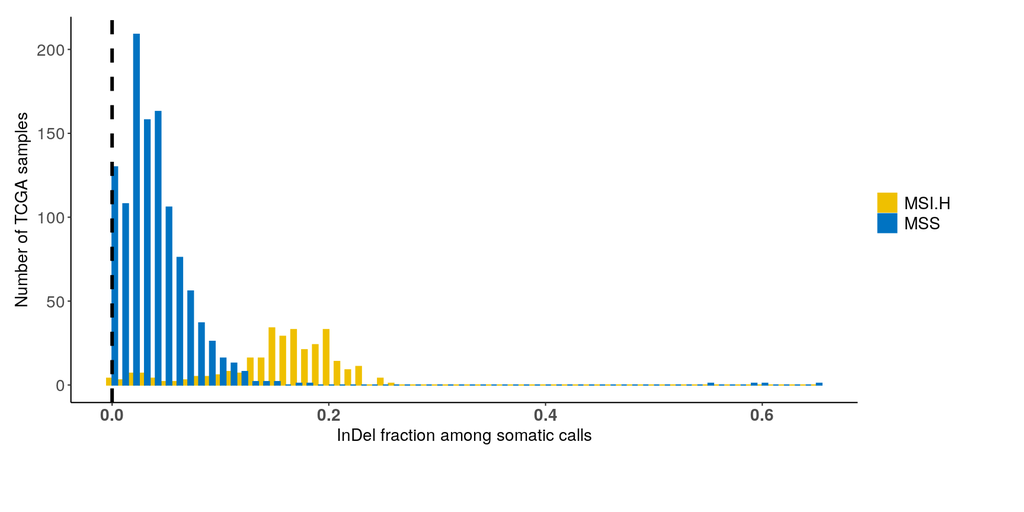

### Somatic coding mutations in MSI-associated genes

*No variants found.*

## Mutational signatures

The number of SNV calls (n = 61 ) is too limited. A minimum of 200 SNVs is currently required for a mutational signature analysis to be performed.

## Clinical trials (Beta)

- Ongoing or planned clinical trials in the relevant tumor type have been retrieved from clinicaltrials.gov, focusing on the subset with molecularly targeted therapies
- Key information entities (interventions/drugs, conditions) in trial records have been mapped to established thesauri ([ChEMBL](https://www.ebi.ac.uk/chembl/), [NCI Thesaurus](https://ncithesaurus.nci.nih.gov/ncitbrowser/), [UMLS/MedGen](https://www.ncbi.nlm.nih.gov/medgen/))
- Results from a text-mining procedure on unstructured trial text (e.g. *inclusion/exclusion criteria*) attempts to highlight the presence of established molecular biomarkers in cancer and relevant therapeutic contexts.

Condition (cancer subtype)

Status

Drug(s)

Drug target(s)

Therapeutic context mentions (text-mined)

Biomarker mentions (text-mined)

Phase

Gender

All

Female

Male

Minimum age

Maximum age

Metastases mentions (text-mined)

|  | NCT_ID | TITLE | OVERALL_STATUS | CONDITION | KEYWORD | INTERVENTION | PHASE | START_DATE | PRIMARY_COMPLETION_DATE | CONDITION_RAW | INTERVENTION_RAW | INTERVENTION_TARGET | BIOMARKER_INDEX | METASTASES_INDEX | GENDER | MINIMUM_AGE | MAXIMUM_AGE |
| --- | --- | --- | --- | --- | --- | --- | --- | --- | --- | --- | --- | --- | --- | --- | --- | --- | --- |
| 1 | NCT02887040 | Study of Antineoplaston Therapy + Radiation vs. Radiation Only in Diffuse, Intrinsic, Brainstem Glioma | Not yet recruiting | Brainstem glioma | Radiotherapy | Antineoplaston A10, Antineoplaston AS2-1 | 3 | 2022-06-01 | 2025-06-20 | Brainstem glioma | Antineoplaston A10, Antineoplaston AS2-1 |  |  |  | All | 3 | 99 |
| 2 | NCT04425798 | Connectivity Alterations After Levetiracetam Application | Not yet recruiting | Glioma | Radiotherapy |  |  | 2022-05-25 | 2022-05-31 | Glioma |  |  |  |  | All | 18 | 75 |
| 3 | NCT02432417 | The Addition of Chloroquine to Chemoradiation for Glioblastoma, | Not yet recruiting | Glioblastoma | Chemoradiotherapy, Immunotherapy, Radiotherapy | Chloroquine | 2 | 2022-01-20 | 2024-01-20 | Glioblastoma | Chloroquine |  |  |  | All | 18 | 70 |
| 4 | NCT04141319 | Effects of Pre-emptive Scalp Infiltration With Ketorolac and Ropivacaine for Post-craniotomy Pain | Not yet recruiting | Neoplasm of brain | Radiotherapy | Ropivacaine, Ketorolac, Epinephrine | 4 | 2021-12-20 | 2022-07-20 | Neoplasm of brain | Epinephrine, Ketorolac, Ropivacaine | ADRA1A, ADRA1B, ADRA1D, ADRA2A, ADRA2B, ADRA2C, ADRB1, ADRB2, ADRB3, PTGS1, PTGS2, SCN10A, SCN11A, SCN1A, SCN2A, SCN3A, SCN4A, SCN5A, SCN7A, SCN9A |  |  | All | 18 | 65 |
| 5 | NCT04319276 | Oral Gallium Maltolate for the Treatment of Relapsed and Refractory Glioblastoma | Not yet recruiting | Glioblastoma | Radiotherapy | Gallium Maltolate | 1 | 2021-07-20 | 2024-07-20 | Glioblastoma | Gallium Maltolate |  |  |  | All | 18 | 75 |
| 6 | NCT02864888 | Effect of Antineoplaston Therapy on the QT/QTc Interval In Subjects With Diffuse, Intrinsic, Brainstem Glioma | Not yet recruiting | Brainstem glioma | Radiotherapy | Antineoplaston A10, Antineoplaston AS2-1 | 3 | 2021-06-20 | 2022-12-20 | Brainstem glioma | Antineoplaston A10, Antineoplaston AS2-1 |  |  |  | All | 3 | 21 |
| 7 | NCT04463979 | Perioperative Evaluation of Cerebellar Tumors | Not yet recruiting | Neoplasm of brain, Cerebellar neoplasm | Radiotherapy |  |  | 2021-04-01 | 2024-04-01 | Cerebellar neoplasm, Neoplasm of brain |  |  |  |  | All | 18 | 99 |
| 8 | NCT04085887 | Panitumumab-IRDye800 to Detect Pediatric Neoplasms During Neurosurgical Procedures | Not yet recruiting | Neoplasm of brain | Radiotherapy | Panitumumab | 1.5 | 2021-02-20 | 2022-09-20 | Neoplasm of brain | Panitumumab | EGFR |  |  | All | 0.5 | 25 |
| 9 | NCT04385277 | Treatment With Dinutuximab, Sargramostim (GM-CSF), and Isotretinoin in Combination With Irinotecan and Temozolomide After Intensive Therapy for People With High-Risk Neuroblastoma (NBL) | Not yet recruiting | Nodular ganglioneuroblastoma | Immunotherapy, Radiotherapy | Sargramostim, Dinutuximab, Irinotecan, Isotretinoin, Temozolomide | 2 | 2021-01-20 | 2022-12-31 | Nodular ganglioneuroblastoma | Dinutuximab, Irinotecan, Isotretinoin, Sargramostim, Temozolomide | CSF2RA, RARA, RARB, RARG, TOP1 | MYCN amplification |  | All | 0 | 30 |
| 10 | NCT04485949 | A Phase 2b Clinical Study With a Combination Immunotherapy in Newly Diagnosed Patients With Glioblastoma Multiforme (GBM) - the ImmuneSense Study | Not yet recruiting | Glioblastoma, Glioblastoma multiforme | Immunotherapy | Immunotherapy, Temozolomide | 2 | 2021-01-20 | 2022-06-20 | Glioblastoma, Glioblastoma multiforme | Immunotherapy, Temozolomide |  |  |  | All | 18 | 70 |

[output cut: 792 more lines]

## Documentation

### Annotation resources

The analysis performed in the cancer genome report is based on the following underlying tools and knowledge resources:

- **Software**
  - [VEP](http://www.ensembl.org/info/docs/tools/vep/index.html) - Variant Effect Predictor (v101)
  - [LOFTEE](https://github.com/konradjk/loftee) - Loss-Of-Function Transcript Effect Estimator (VEP plugin) (v1.0.3)
  - vcfanno - Rapid annotation of VCF with other VCFs/BEDs/tabixed files (v0.3.2)
  - MutationalPatterns - Comprehensive genome-wide analysis of mutational processes (v2.0.0)
  - vcf2maf - VCF to MAF conversion (v1.6.17)
  - vcf-validator - Validation suite for Variant Call Format (VCF) files, implemented using C++11 (v0.9.3)
  - [maftools](https://bioconductor.org/packages/release/bioc/vignettes/maftools/inst/doc/maftools.html) - Summary, analysis and visualization of MAF files (v2.4.12)
  - vt - A tool set for short variant discovery in genetic sequence data (v0.57721)
- **Databases/datasets**
  - [GENCODE](https://www.gencodegenes.org/) - high quality reference gene annotation and experimental validation (release 35/19)
  - dbNSFP - Database of non-synonymous functional predictions (20200616 (v4.1))
  - [Pfam](http://pfam.xfam.org) - Collection of protein families/domains (2020_05 (v33.1))
  - [TCGA](https://cancergenome.nih.gov) - The Cancer Genome Atlas - somatic mutations (20200722 (v25))
  - [ICGC-PCAWG](http://docs.icgc.org/pcawg/) - ICGC-Pancancer Analysis of Whole Genomes - somatic mutations (2020_01)
  - [TCGA-PCDM](http://cancergenome.nih.gov) - Putative Cancer Driver Mutations based on multiple discovery approaches (2019)
  - [UniProtKB](http://www.uniprot.org) - Comprehensive resource of protein sequence and functional information (2020_04)
  - [CORUM](http://mips.helmholtz-muenchen.de/corum/) - The comprehensive resource of mammalian protein complexes (20180903 (release 3.0))
  - [gnomAD](http://gnomad.broadinstitute.org) - Germline variant frequencies exome-wide (r2.1 (October 2018))
  - [COSMIC](https://cancer.sanger.ac.uk/cosmic) - Catalogue of somatic mutations in cancer (90)
  - [dbSNP](http://www.ncbi.nlm.nih.gov/SNP/) - Database of short genetic variants (153)
  - 1000Genomes - Germline variant frequencies genome-wide (20130502 (phase 3))
  - [DisGenet](http://www.disgenet.org) - Database of gene-disease associations (2020_05 (v7.0))
  - [DoCM](http://docm.genome.wustl.edu) - Database of curated mutations (release 3.2)
  - [CancerHotspots](http://cancerhotspots.org) - A resource for statistically significant mutations in cancer (2017)
  - [ClinVar](https://www.ncbi.nlm.nih.gov/clinvar) - Database of genomic variants of clinical significance (20200803)
  - [CancerMine](http://bionlp.bcgsc.ca/cancermine/) - Literature-mined database of tumor suppressor genes/proto-oncogenes (20200908 (release 28))
  - [OncoTree](http://oncotree.mskcc.org/) - Open-source ontology developed at MSK-CC for standardization of cancer type diagnosis (2020_04_01)
  - [DiseaseOntology](http://disease-ontology.org) - Standardized ontology for human disease (20200915)
  - [EFO](https://github.com/EBISPOT/efo) - Experimental Factor Ontology (v3.22)
  - [OncoScore](https://bioconductor.org/packages/release/bioc/html/OncoScore.html) - Literature-based ranking of gene-cancer association (20191227)
  - [OpenTargetPlatform](https://www.targetvalidation.org) - Comprehensive and robust data integration for access to potential drug targets associated with disease (2020_06)
  - [ChEMBL](https://www.ebi.ac.uk/chembl/) - Manually curated database of bioactive molecules (20200518 (v27))
  - [KEGG](http://www.genome.jp/kegg/pathway.html) - Knowledge base on the molecular interaction, reaction and relation networks (20200910)
  - [CIViC](http://civic.genome.wustl.edu) - Clinical interpretations of variants in cancer (20200920)
  - [CGI](http://cancergenomeinterpreter.org/biomarkers) - Cancer Genome Interpreter Cancer Biomarkers Database (20180117)

### Report content

#### SNVs/InDels

The prioritization of SNV and InDels found in the tumor sample is done according to a four-tiered structure, adopting the joint consensus recommendation by AMP/ACMG [Li et al., 2017](https://www.ncbi.nlm.nih.gov/pubmed/27993330).

- **TIER 1: Variants of strong clinical significance** - constitutes variants linked to predictive, prognostic, or diagnostic biomarkers in the [CIViC database](http://civic.genome.wustl.edu) and the [Cancer Biomarkers Database](https://www.cancergenomeinterpreter.org/biomarkers) that are
  - Found within the same tumor type/class as specified by the user, **AND**
  - Of strong clinical evidence (i.e. part of guidelines, validated or discovered in late clinical trials ([CIViC evidence levels A/B](https://civic.readthedocs.io/en/latest/model/evidence/level.html)))
  - overlap between variants in the tumor sample and reported biomarkers must occur at the *exact variant level* or at the *codon/exon level*
- **TIER 2: Variants of potential clinical significance** - constitutes other variants linked to predictive, prognostic, or diagnostic biomarkers in the [CIViC database](http://civic.genome.wustl.edu) and the [Cancer Biomarkers Database](https://www.cancergenomeinterpreter.org/biomarkers) that are either
  - Of strong clinical evidence in other tumor types/classes than the one specified by the user, **OR**
  - Of weak clinical evidence (early trials, case reports etc. ([CIViC evidence levels C/D/E](https://civic.readthedocs.io/en/latest/model/evidence/level.html)))) in the same tumor type/class as specified by the user
  - overlap between variants in the tumor sample and reported biomarkers must occur at the *exact variant level* or at the *codon/exon level*
- **TIER 3: Variants of uncertain clinical significance** - includes other coding variants found in oncogenes or tumor suppressor genes
  - Status as oncogenes and/or tumor suppressors genes are done according to the following scheme in PCGR:
    - Five or more publications in the biomedical literature that suggests an oncogenic/tumor suppressor role for a given gene (as collected from the [CancerMine text-mining resource](http://bionlp.bcgsc.ca/cancermine/)), **OR**
    - At least two publications from CancerMine that suggests an oncogenic/tumor suppressor role for a given gene **AND** an existing record for the same gene as a tumor suppressor/oncogene in the [Network of Cancer Genes (NCG)](http://ncg.kcl.ac.uk/)
    - Status as oncogene is ignored if a given gene has three times as much (literature evidence) support for a role as a tumor suppressor gene (and vice versa)
    - Oncogenes/tumor suppressor candidates from CancerMine/NCG that are found in the [curated list of false positive cancer drivers compiled by Bailey et al. (Cell, 2018)](https://www.ncbi.nlm.nih.gov/pubmed/30096302) have been excluded
- **TIER 4** - includes other protein-coding variants
  - *Protein-coding* refers here to variants with the following consequences:
  - missense_variant
  - stop_gain/stop_loss
  - frameshift_variant
  - inframe_insertions/inframe_deletions
  - splice_donor_variant/splice_acceptor_variant
  - start_loss
- **NONCODING** - includes other non-(protein)coding variants

A complete list of reported biomarkers that associate with variants in the tumor sample (not necessarily qualifying for assignment to TIER 1/TIER 2) is also shown in a separate section.

#### Somatic copy number aberrations

Somatic copy number aberrations identified in the tumor sample are classified into **two main tiers**:

- **TIER 1: Aberrations of strong clinical significance** - constitutes amplified/lost genes linked to predictive, prognostic, or diagnostic biomarkers in the [CIViC database](http://civic.genome.wustl.edu) and the [Cancer Biomarkers Database](https://www.cancergenomeinterpreter.org/biomarkers) that are
  - Found within the same tumor type/class as specified by the user, **AND**
  - Of strong clinical evidence (i.e. part of guidelines, validated or discovered in late clinical trials ([CIViC evidence levels A/B](https://civic.readthedocs.io/en/latest/model/evidence/level.html)))
- **TIER 2: Aberrations of potential clinical significance** - constitutes amplified/lost genes linked to predictive, prognostic, or diagnostic biomarkers in the [CIViC database](http://civic.genome.wustl.edu) and the [Cancer Biomarkers Database](https://www.cancergenomeinterpreter.org/biomarkers) that are either
  - Of strong clinical evidence in other tumor types/classes than the one specified by the user, **OR**
  - Of weak clinical evidence (early trials, case reports etc. ([CIViC evidence levels C/D/E](https://civic.readthedocs.io/en/latest/model/evidence/level.html)))) in the same tumor type/class as specified by the user

Included in the report is also a complete list of **all oncogenes subject to amplifications**, **tumor suppressor genes subject to homozygous deletions**, and **other drug targets subject to amplifications**

#### Mutational signatures

The set of somatic mutations observed in a tumor reflects the varied mutational processes that have been active during its life history, providing insights into the routes taken to carcinogenesis. Exogenous mutagens, such as tobacco smoke and ultraviolet light, and endogenous processes, such as APOBEC enzymatic family functional activity or DNA mismatch repair deficiency, result in characteristic patterns of mutation. Mutational signatures can have significant clinical impact in certain tumor types ([Póti et al., 2019](https://www.ncbi.nlm.nih.gov/pubmed/31727117), [Ma et al., 2018](https://www.ncbi.nlm.nih.gov/pubmed/30120226))

The **MutationalPatterns** package ([Blokzijl et al., 2018](https://www.ncbi.nlm.nih.gov/pubmed/29695279)) is used to estimate the relative contribution of known mutational signatures in a single tumor sample. MutationalPatterns makes an optimal reconstruction of the mutations observed in a given sample with a [reference collection of n = 67 mutational signatures](https://www.ncbi.nlm.nih.gov/pubmed/32025018). By default, we restrict the signatures in the reference collection to those already observed in the tumor type in question (i.e. from large-scale *de novo* signature extraction on ICGC tumor samples).

**NOTE**: This sample contains too few variants for estimation of mutational signature contributions

#### Tumor mutational burden (TMB)

Tumor mutational load or mutational burden is a measure of the number of mutations within a tumor genome, defined as the total number of mutations per coding area of a tumour genome. TMB may serve as a proxy for determining the number of neoantigens per tumor, which in turn has implications for response to immunetherapy. For estimation of TMB, PCGR employs the same approach as was outlined in a recently published large-scale study of TMB [(Chalmers et al. 2017)](https://www.ncbi.nlm.nih.gov/pubmed/28420421), i.e. counting all somatic base substitutions and indels in the protein-coding regions of the sequencing assay, including synonymous alterations.

#### MSI classification

Microsatellite instability (MSI) is the result of impaired DNA mismatch repair and constitutes a cellular phenotype of clinical significance in many cancer types, most prominently colorectal cancers, stomach cancers, endometrial cancers, and ovarian cancers ([Cortes-Ciriano et al., 2017](https://www.ncbi.nlm.nih.gov/pubmed/28585546)). We have built a statistical MSI classifier from somatic mutation profiles that separates *MSI.H* (MSI-high) from *MSS* (MS stable) tumors. The MSI classifier was trained using 999 exome-sequenced TCGA tumor samples with known MSI status (i.e. assayed from mononucleotide markers), and obtained a [positive predictive value](https://en.wikipedia.org/wiki/Positive_and_negative_predictive_values#Positive_predictive_value) of 98.9% and a [negative predictive value](https://en.wikipedia.org/wiki/Positive_and_negative_predictive_values#Negative_predictive_value) of 98.8% on an independent test set of 427 samples. Details of the MSI classification approach can be found [here](http://rpubs.com/sigven/msi_classification_v3).

Note that the MSI classifier is applied only for WGS/WES tumor-control sequencing assays.

#### Kataegis

Kataegis describes a pattern of localized hypermutations identified in some cancer genomes, in which a large number of highly-patterned basepair mutations occur in a small region of DNA (ref Wikipedia). Kataegis is prevalently seen among breast cancer patients, and it is also exists in lung cancers, cervical, head and neck, and bladder cancers, as shown in the results from tracing APOBEC mutation signatures (ref Wikipedia). PCGR implements the kataegis detection algorithm outlined in the [KataegisPortal R package](https://github.com/MeichunCai/KataegisPortal).

Explanation of key columns in the resulting table of potential kataegis events:

- **weight.C>X**: proportion of C>X mutations
- **confidence**: confidence degree of potential kataegis events (range: 0 to 3)
  - 0 - a hypermutation with weight.C>X < 0.8;
  - 1 - one hypermutation with weight.C>X >= 0.8 in a chromosome;
  - 2 - two hypermutations with weight.C>X >= 0.8 in a chromosome;
  - 3 - high confidence with three or more hypermutations with weight.C>X >= 0.8 in a chromosome)

### References

Alexandrov, Ludmil B, Jaegil Kim, Nicholas J Haradhvala, Mi Ni Huang, Alvin Wei Tian Ng, Yang Wu, Arnoud Boot, et al. 2020. “The Repertoire of Mutational Signatures in Human Cancer.” *Nature* 578 (7793): 94–101. http://dx.doi.org/10.1038/s41586-020-1943-3.

Alexandrov, Ludmil B, Serena Nik-Zainal, David C Wedge, Samuel A J R Aparicio, Sam Behjati, Andrew V Biankin, Graham R Bignell, et al. 2013. “Signatures of Mutational Processes in Human Cancer.” *Nature* 500 (7463): 415–21. https://doi.org/10.1038/nature12477.

Bailey, Matthew H, Collin Tokheim, Eduard Porta-Pardo, Sohini Sengupta, Denis Bertrand, Amila Weerasinghe, Antonio Colaprico, et al. 2018. “Comprehensive Characterization of Cancer Driver Genes and Mutations.” *Cell* 173 (2): 371–385.e18. http://dx.doi.org/10.1016/j.cell.2018.02.060.

Blokzijl, Francis, Roel Janssen, Ruben van Boxtel, and Edwin Cuppen. 2018. “MutationalPatterns: Comprehensive Genome-Wide Analysis of Mutational Processes.” *Genome Med.* 10 (1): 33. http://dx.doi.org/10.1186/s13073-018-0539-0.

Chalmers, Zachary R, Caitlin F Connelly, David Fabrizio, Laurie Gay, Siraj M Ali, Riley Ennis, Alexa Schrock, et al. 2017. “Analysis of 100,000 Human Cancer Genomes Reveals the Landscape of Tumor Mutational Burden.” *Genome Med.* 9 (1): 34. https://doi.org/10.1186/s13073-017-0424-2.

Cortes-Ciriano, Isidro, Sejoon Lee, Woong-Yang Park, Tae-Min Kim, and Peter J Park. 2017. “A Molecular Portrait of Microsatellite Instability Across Multiple Cancers.” *Nat. Commun.* 8: 15180. https://doi.org/10.1038/ncomms15180.

Griffith, Malachi, Nicholas C Spies, Kilannin Krysiak, Joshua F McMichael, Adam C Coffman, Arpad M Danos, Benjamin J Ainscough, et al. 2017. “CIViC Is a Community Knowledgebase for Expert Crowdsourcing the Clinical Interpretation of Variants in Cancer.” *Nat. Genet.* 49 (2): 170–74. http://dx.doi.org/10.1038/ng.3774.

Lever, Jake, Eric Y Zhao, Jasleen Grewal, Martin R Jones, and Steven J M Jones. 2019. “CancerMine: A Literature-Mined Resource for Drivers, Oncogenes and Tumor Suppressors in Cancer.” *Nat. Methods* 16 (6): 505–7. http://dx.doi.org/10.1038/s41592-019-0422-y.

Li, Marilyn M, Michael Datto, Eric J Duncavage, Shashikant Kulkarni, Neal I Lindeman, Somak Roy, Apostolia M Tsimberidou, et al. 2017. “Standards and Guidelines for the Interpretation and Reporting of Sequence Variants in Cancer: A Joint Consensus Recommendation of the Association for Molecular Pathology, American Society of Clinical Oncology, and College of American Pathologists.” *J. Mol. Diagn.* 19 (1): 4–23. https://dx.doi.org/10.1016%2Fj.jmoldx.2016.10.002.

Ma, Jennifer, Jeremy Setton, Nancy Y Lee, Nadeem Riaz, and Simon N Powell. 2018. “The Therapeutic Significance of Mutational Signatures from DNA Repair Deficiency in Cancer.” *Nat. Commun.* 9 (1): 3292. http://dx.doi.org/10.1038/s41467-018-05228-y.

Póti, Ádám, Hella Gyergyák, Eszter Németh, Orsolya Rusz, Szilárd Tóth, Csenger Kovácsházi, Dan Chen, et al. 2019. “Correlation of Homologous Recombination Deficiency Induced Mutational Signatures with Sensitivity to PARP Inhibitors and Cytotoxic Agents.” *Genome Biol.* 20 (1): 240. http://dx.doi.org/10.1186/s13059-019-1867-0.

Repana, Dimitra, Joel Nulsen, Lisa Dressler, Michele Bortolomeazzi, Santhilata Kuppili Venkata, Aikaterini Tourna, Anna Yakovleva, Tommaso Palmieri, and Francesca D Ciccarelli. 2019. “The Network of Cancer Genes (NCG): A Comprehensive Catalogue of Known and Candidate Cancer Genes from Cancer Sequencing Screens.” *Genome Biol.* 20 (1): 1. http://dx.doi.org/10.1186/s13059-018-1612-0.

Tamborero, David, Carlota Rubio-Perez, Jordi Deu-Pons, Michael P Schroeder, Ana Vivancos, Ana Rovira, Ignasi Tusquets, et al. 2018. “Cancer Genome Interpreter Annotates the Biological and Clinical Relevance of Tumor Alterations.” *Genome Med.* 10 (1): 25. http://dx.doi.org/10.1186/s13073-018-0531-8.

Yin, Xia, Rui Bi, Pengfei Ma, Shengzhe Zhang, Yang Zhang, Yunheng Sun, Yi Zhang, et al. 2020. “Multiregion Whole-Genome Sequencing Depicts Intratumour Heterogeneity and Punctuated Evolution in Ovarian Clear Cell Carcinoma.” *J. Med. Genet.* 57 (9): 605–9. http://dx.doi.org/10.1136/jmedgenet-2019-106418.

**MEDICAL DISCLAIMER**:*The information contained in this cancer genome report is intended for research purposes only. We make no representations or warranties of any kind, expressed or implied, about the completeness, accuracy, reliability, suitability or availability with respect to the genome report or the information, products, services, for interpretation or use in clinical practice, or otherwise contained in the report for any purpose. Any reliance you place on information in the report is therefore strictly at your own risk. In no event will we be liable for any loss or damage including without limitation, indirect or consequential loss or damage, or any loss or damage whatsoever arising from loss of data or profits arising out of, or in connection with, the use of this genome report.*